# individual2.Rmd

Alex Beagle

9/12/2019

1. About half of the ratings fall between 3 and 3.5, which makes sense. These chocolate bars were seen as satisfactory. There are much fewer chocolate bars with ratings between 1 and 2.5, but these were viewed as being unpleasant and disappointing. Finally there is one chocolate bar that has a rating of 5. The chocolate bars with ratings of 1 and 5 can be considered outliers, considering that 75% of the data falls between ratings of about 2.25 to 4.

```r
choco <- read.csv("https://raw.githubusercontent.com/lbchu/ds202_labs/master/choco.csv")
head(choco)
```

```
##    Company Specific.Bean.Origin  REF Review.Date Cocoa.Pct
## 1 A. Morin          Agua Grande 1876        2016        63
## 2 A. Morin                Kpime 1676        2015        70
## 3 A. Morin               Panama 1011        2013        70
## 4 A. Morin           Madagascar 1011        2013        70
## 5 A. Morin               Brazil 1011        2013        70
## 6 A. Morin             Equateur 1011        2013        70
##   Company.Location Rating Bean.Type Broad.Bean.Origin
## 1           France   3.75                    Sao Tome
## 2           France   2.75                        Togo
## 3           France   2.75                      Panama
## 4           France   3.00   Criollo        Madagascar
## 5           France   3.25                      Brazil
## 6           France   3.75                     Ecuador
```

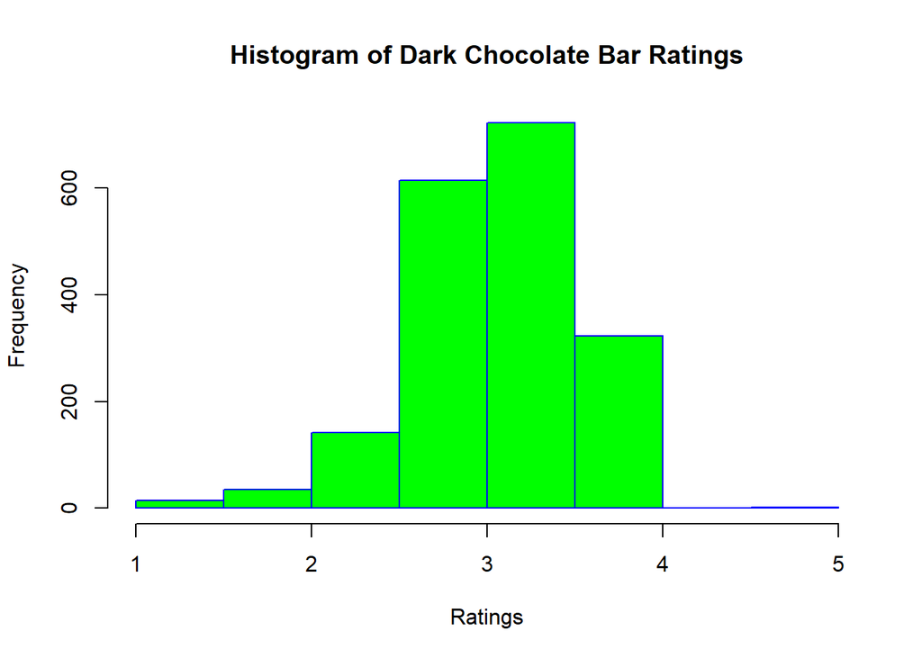

```r
hist(choco$Rating, main = "Histogram of Dark Chocolate Bar Ratings", xlab ="Ratings", border = "blue", col = "green")
```

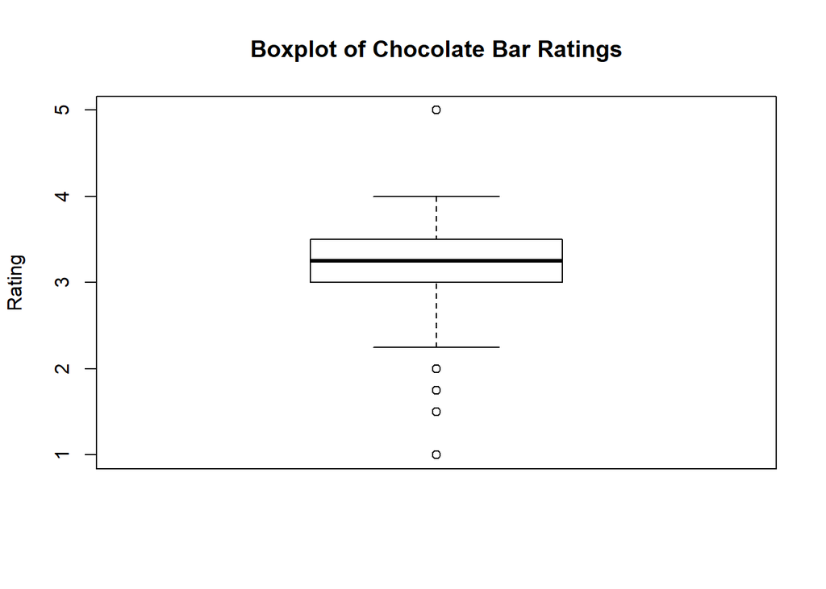

```r
boxplot(choco$Rating, main = "Boxplot of Chocolate Bar Ratings", ylab = "Rating")
```

2.According to the scatterplot, ratings do not depend on the cocoa percentage of a chocolate bar. The distribution seems fairly uniform among the various cocoa percentages.

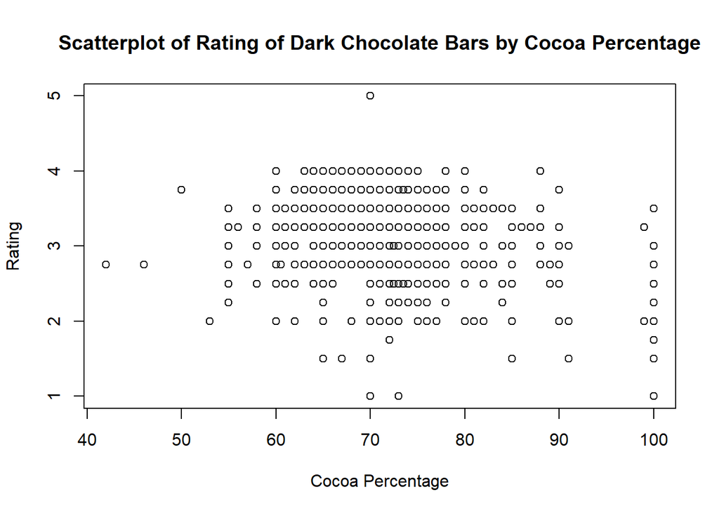

```r
plot(choco$Cocoa.Pct, choco$Rating, ylab = "Rating", xlab = "Cocoa Percentage", main = "Scatterplot of Rating of Dark Chocolate Bars by Cocoa Percentage")
```

3. The variable representing company locations is a “factor”, rather than a “character” variable. The two differ in that a piece of text in R is comprised of a sequence of characters. A factor, on the other hand, are easier to work with, and they are used to work with categorical variables with a fixed and known set of possible values.

```r
class(choco$Company.Location)
```

```
## [1] "factor"
```